# meta123

Rayna M Harris

April 6 2017

Here is a brief overview of the samples being compared.

```r
str(colData)
```

```
## 'data.frame':    53 obs. of  14 variables:
##  $ RNAseqID : Factor w/ 53 levels "100-CA1-1","100-CA1-2",..: 1 2 3 4 5 6 7 8 9 10 ...
##  $ Mouse    : Factor w/ 17 levels "15-100","15-143B",..: 1 1 1 1 1 1 1 1 1 1 ...
##  $ year     : int  2015 2015 2015 2015 2015 2015 2015 2015 2015 2015 ...
##  $ Genotype : Factor w/ 1 level "WT": 1 1 1 1 1 1 1 1 1 1 ...
##  $ jobnumber: Factor w/ 2 levels "JA16444","JA16268": 1 1 1 1 1 1 1 1 1 1 ...
##  $ Region   : Factor w/ 3 levels "CA1","CA3","DG": 1 1 1 2 2 3 3 1 1 1 ...
##  $ Treatment: Factor w/ 3 levels "control","homecage",..: 2 2 2 2 2 2 2 2 2 2 ...
##  $ Conflict : Factor w/ 2 levels "Conflict","NoConflict": NA NA NA NA NA NA NA NA NA NA ...
##  $ APA      : Factor w/ 2 levels "Yoked","Trained": NA NA NA NA NA NA NA NA NA NA ...
##  $ Method   : Factor w/ 3 levels "control","dissociated",..: 1 1 1 1 1 1 1 2 2 2 ...
##  $ dodgy    : Factor w/ 3 levels "allgood","slice",..: 1 1 1 1 1 1 1 1 1 1 ...
##  $ daytime  : Factor w/ 3 levels "beforenoon","norecord",..: 2 2 2 2 2 2 2 2 2 2 ...
##  $ Slice    : int  1 2 3 1 4 2 3 1 2 3 ...
##  $ Date     : Factor w/ 13 levels "7/15/15","7/18/15",..: 8 8 8 8 8 8 8 8 8 8 ...
```

```r
summary(colData)
```

```
##       RNAseqID      Mouse         year      Genotype   jobnumber  Region
##  100-CA1-1: 1   15-100 :13   Min.   :2015   WT:53    JA16444:49   CA1:21
##  100-CA1-2: 1   15-146B: 3   1st Qu.:2015            JA16268: 4   CA3:14
##  100-CA1-3: 1   15-147 : 3   Median :2015                         DG :18
##  100-CA3-1: 1   15-148 : 3   Mean   :2015
##  100-CA3-4: 1   15-148B: 3   3rd Qu.:2015
##  100-DG-2 : 1   15-143C: 3   Max.   :2015
##  (Other)  :47   (Other):25
##       Treatment        Conflict       APA             Method
##  control   :21   Conflict  :12   Yoked  :21   control    : 7
##  homecage  :19   NoConflict:22   Trained:13   dissociated: 6
##  consistent:13   NA's      :19   NA's   :19   homogenized:40
##
##
##
##
##      dodgy          daytime       Slice            Date
##  allgood:47   beforenoon: 8   Min.   :1.000   9/28/15:13
##  slice  : 4   norecord  :42   1st Qu.:1.000   7/18/15: 5
##  ephys  : 2   earlyAM   : 3   Median :2.000   7/10/15: 5
##                               Mean   :2.377   7/24/15: 5
##                               3rd Qu.:3.000   7/29/15: 5
##                               Max.   :4.000   7/23/15: 3
##                                               (Other):17
```

Some read statistics

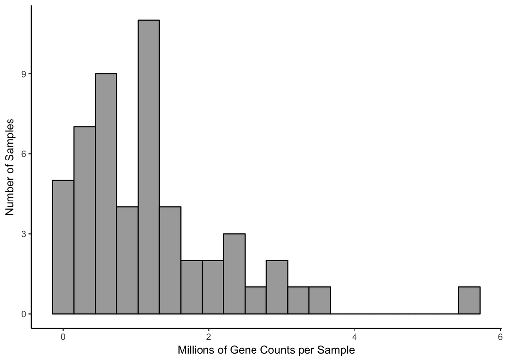

This PCA gives an overview of the variability between samples using the a large matrix of log transformed gene expression data. You can see that the bigges difference is between DG punches and the CA1 and CA3 punches. CA1 and CA3 samples have similar transcriptomes. The homogenized CA1 samples have the most similar transcriptonal profiles as evidenced by their tight clustering.

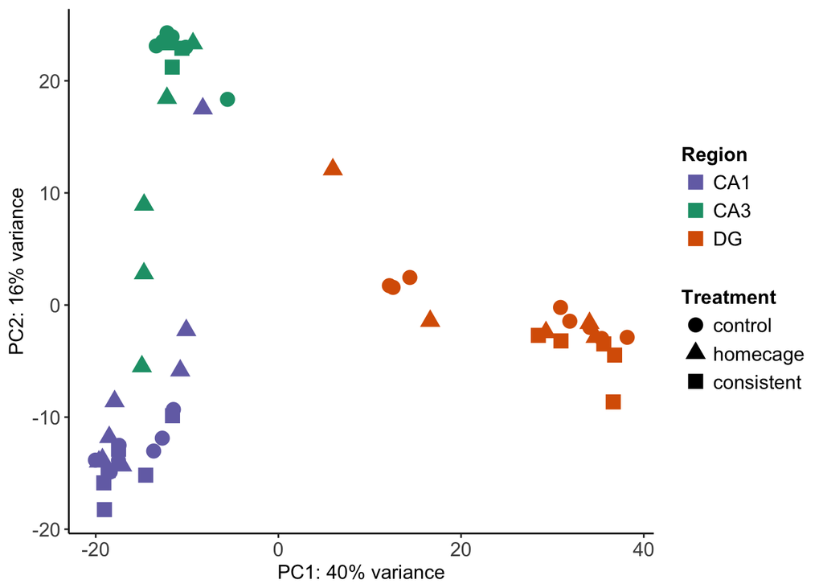

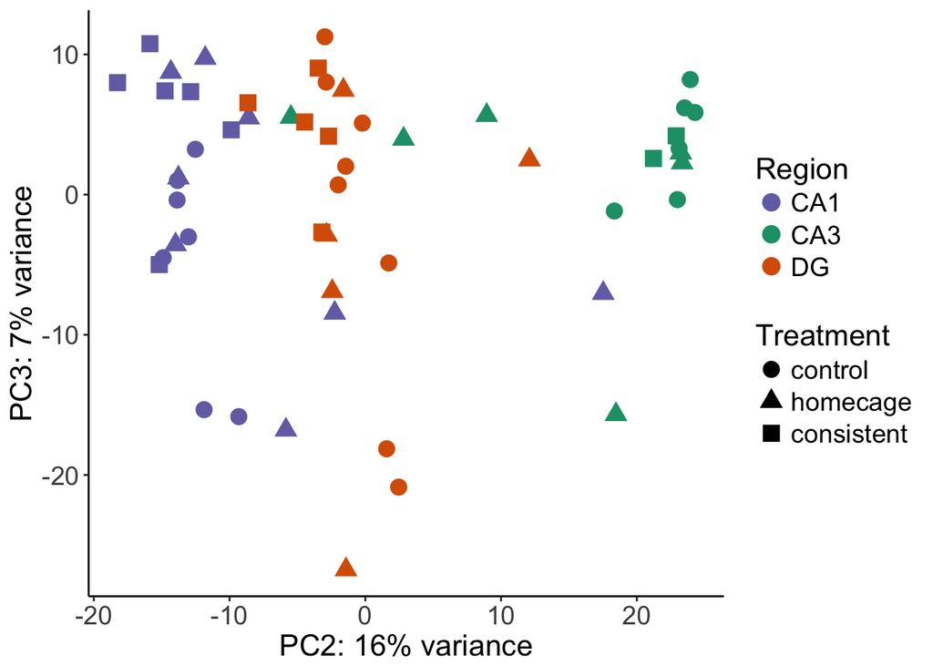

Now, we can calulate the number of significant genes by contrast by contrast. The first number displayed is not corrected for mutiple hypothesis testing but the second one is.

```r
## DEG by contrasts
source("resvalsfunction.R")
contrast1 <- resvals(contrastvector = c('Region', 'CA1', 'DG'), mypval = 0.1)
```

```
## [1] 4461
## [1] 2333
```

```r
contrast2 <- resvals(contrastvector = c('Region', 'CA3', 'DG'), mypval = 0.1)
```

```
## [1] 5373
## [1] 3249
```

```r
contrast3 <- resvals(contrastvector = c('Region', 'CA1', 'CA3'), mypval = 0.1)
```

```
## [1] 3794
## [1] 1607
```

Now, we can view a histogram of the distribution

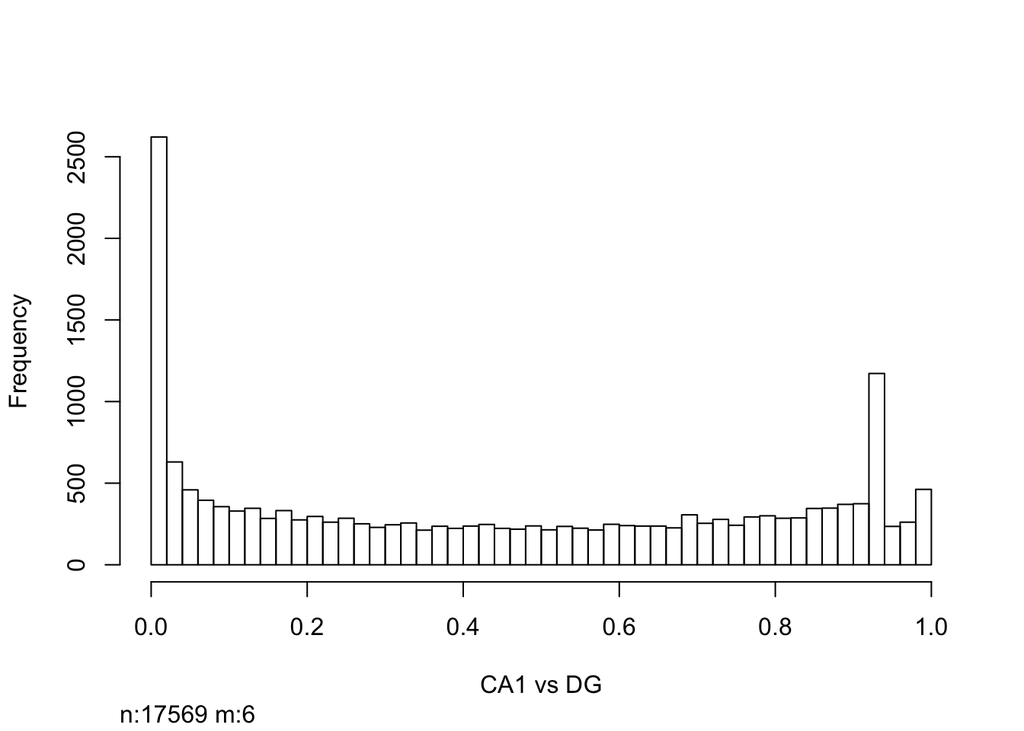

```
## [1] 1
```

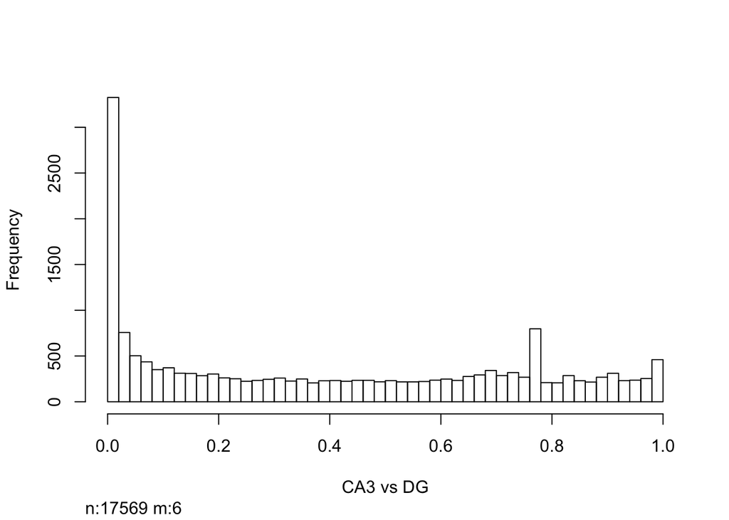

```
## [1] 1
```

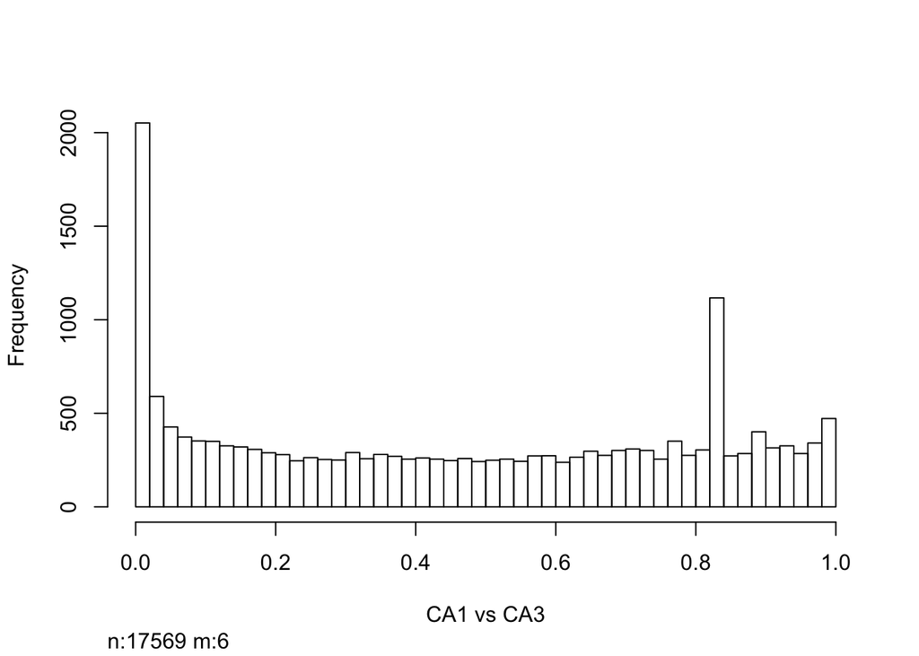

```
## [1] 1
```

# heatmaps

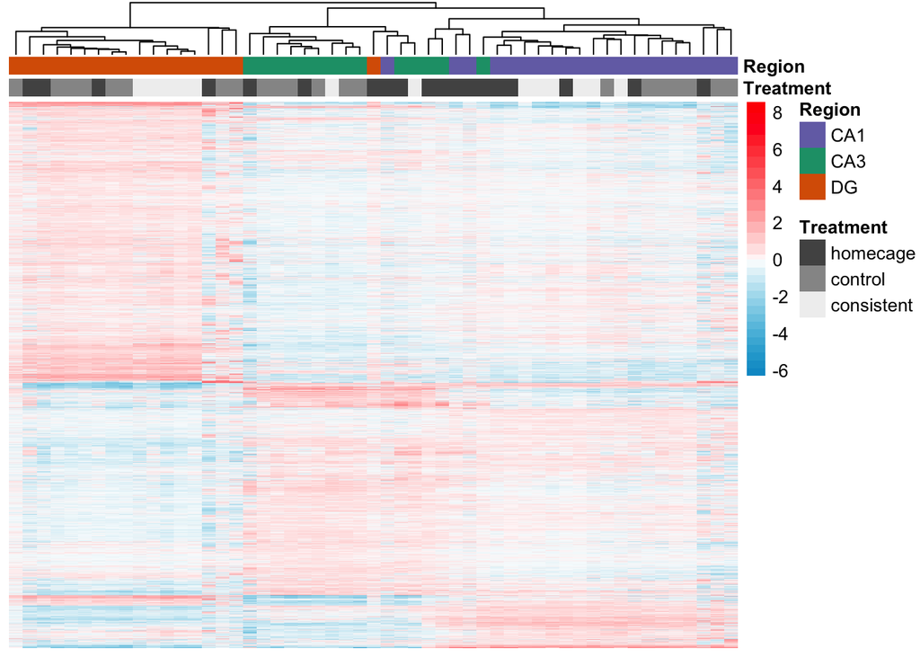

```
FALSE [1] 22485    53
```

[output not shown]

```
FALSE
FALSE    0    1    2    3    4    5    6    7    8    9   10   11   12   13   14
FALSE 4206  369  335  226  204  175  169  126  129   88   92   83   81   75   63
FALSE   15   16   17   18   19   20   21   22   23   24   25   26   27   28   29
FALSE   72   70   68   64   57   67   58   54   51   57   49   48   43   48   47
```